# Loan dataset analysis

Have you ever wondered which borrower is the best for you to lend to? In this analysis we will explore how you can make the right decision in choosing your borrowers and how can you relate between different borrowers based on their scores. But first lets get a basic insights about the dataset we are using. The dataset contains the borrowers data in which we are going to analyse. \

The data we are using is called "The loan dataset" which contains data about borrowers including their loans history, borrower rates (interest rates), their jobs, and more.  
It also provides useful information to help lenders make the right decision in choosing their borrowers and defining the appropriate interests.  
The dataset is (94843 rows × 69 columns) So we are going to analyse on these 94843 and see what questions can help the business.

## 1. What is the most abundant status of loans made by the borrowers in this dataset?

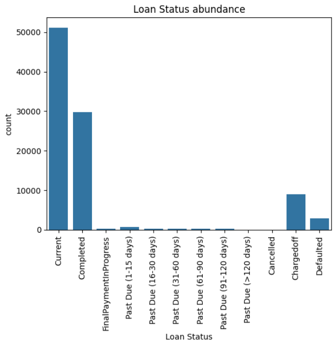

In this dataset, most borrowers are currently in debt means they are currently still repaying loans, they are the most in this data.  
The second most abundant status are borrowers who have their debt completed which is a good sign that there are large number of borrowers who are free from debts.  
"Charged off" is when lender writes off the loan as a loss because the borrowers didn't pay their debts and the lenders at this point should get legal action  
"Defaulted" are borrowers who didn't repay some of their debts in the appropriate time. \

The "Charged off" and "Defaulted" borrowers are relatively less in number than the "Current" or "Completed" borrowers.  
Others are not important in this analysis but we had a good indication about what type borrowers we are working on.

## 2. How can the Employment status of the borrowers affect on the borrower rate?

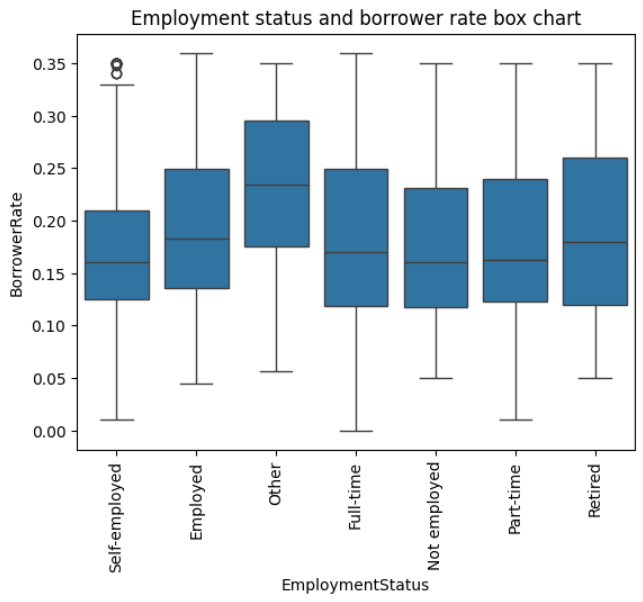

As we can see in this chart, borrowers who are "others" tend to have more interest to payoff than other categories which makes sense as these borrowers' income is unknown or diverse which is unstable and they have more risky loans that can cause losses to the lender.  
Meanwhile the borrowers who are employed in general don't payoff high interest rates as they are finanially stable.  
But a question arrises, Why the not employed borrowers' interest rate is not as high as "others" since they should have unstable incomes that results in increasing the risk of the loans?  
It's important to understand that not being an employee doesn't mean they have unstable incomes, they can be business men who have stable incomes mixed with those who are not employed and have unstable incomes so the interquartile range (the box range) and the median marker are pulled downwards.  
Also business me should be more rare than other not employed borrowers.  
Let's check about this insight.

## 3. Can the not employed borrowers contain business men?

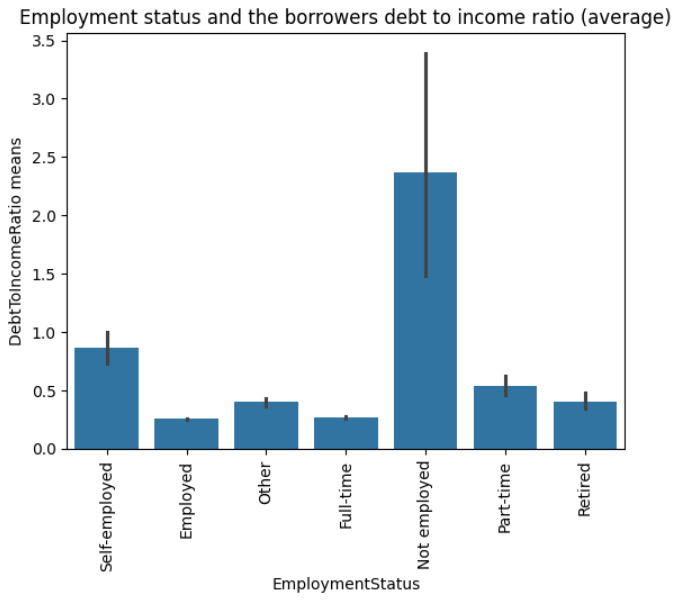

If we compared them to their debts we can see that the average which is mathematically affected by the number of the not employed borrowers' debts is very higher compared to others, this shows that there was infact many borrowers that fall under this category who had more debts (had unstable income) made the average value of the debts to be very high.  
But we should confirm that there are also business men or borrowers who have stable income in this category.

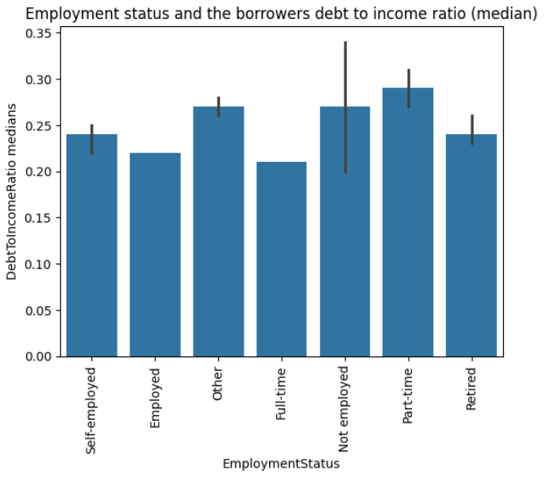

In the median version of this chart, it shows to us that indeed, the not employed category contains a number of borrowers with stable incomes (like business men) In which the median didn't care about the number of those unstable income borrowers but rather the exact center of the debt to the income ratio values.

## 4. Who should i trust the most?

It turned out that the "others" or "not employed" borrowers tend to have more debts than the employed borrowers.  
This means lenders should trust more the employed borrowers as they can get higher **profit** than the not employed borrowers.  
As long as the borrower is labelled "Not employed" without any further details then it's **safer** to lend borrowers who are employed by any type.

## 5. How can the estimated loss be related to the prosper score?

The prosper score is a scale that shows how trustworthy is this specific borrower, higher prosper score indicates that this borrower will be likely to pay debts to the loan on time and less likely to become "charged off" or "defaulted". \

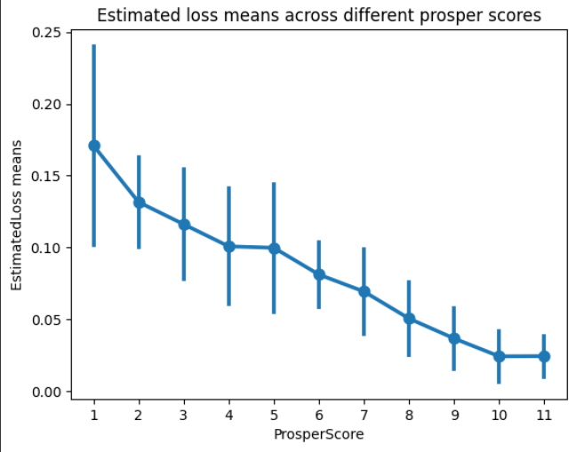

This visualization shows that borrowers with higher prosper score will guarantee to the lenders less loses when they pay their debt on the right time.  
This means lenders should choose people with **High prosper score** to guarantee the least loses to the loan.

## 6. Do really lenders trust borrowers with higher prosper score?

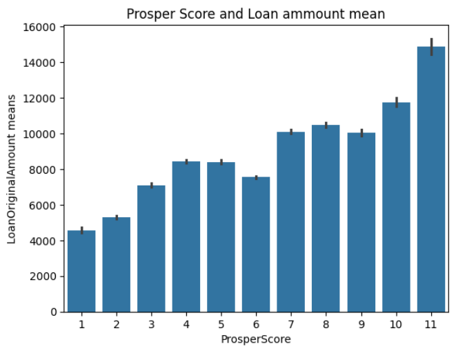

```python
!jupyter nbconvert --to html "/content/Explaination.ipynb"
```

```
[NbConvertApp] Converting notebook /content/Explaination.ipynb to html
[NbConvertApp] Writing 667914 bytes to /content/Explaination.html
```